# Reproducible Research: Peer Assessment 1

## Loading and preprocessing the data

Load required packages and read table as “data.table” and enforce type “Date” on corressponding column.

```r
library(lattice)
library(data.table)

unzip('activity.zip')
activity= fread('activity.csv')
activity[, date := as.Date(activity$date)]
```

```
##        steps       date interval
##     1:    NA 2012-10-01        0
##     2:    NA 2012-10-01        5
##     3:    NA 2012-10-01       10
##     4:    NA 2012-10-01       15
##     5:    NA 2012-10-01       20
##    ---
## 17564:    NA 2012-11-30     2335
## 17565:    NA 2012-11-30     2340
## 17566:    NA 2012-11-30     2345
## 17567:    NA 2012-11-30     2350
## 17568:    NA 2012-11-30     2355
```

## What is mean total number of steps taken per day?

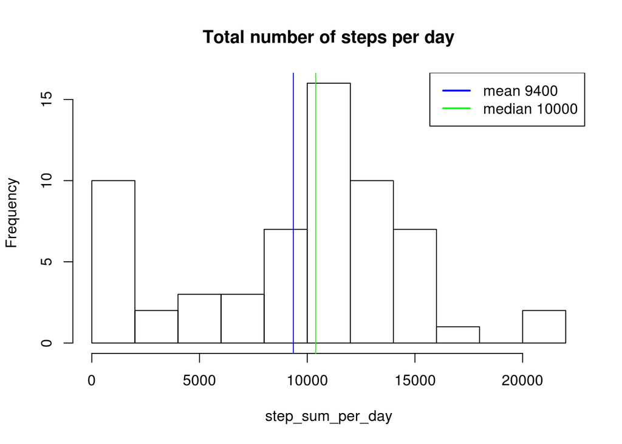

```r
step_sum_per_day= activity[, sum(steps, na.rm=TRUE), by=date]$V1

hist(step_sum_per_day, breaks=10, main='Total number of steps per day')

abline(v=mean(step_sum_per_day), col='blue')
abline(v=median(step_sum_per_day), col='green')
legend('topright',
         c(paste('mean', signif(mean(step_sum_per_day),2)),
             paste('median', signif(median(step_sum_per_day),2))
             ),
         col=c('blue','green'),
         lwd=2
     )
```

## What is the average daily activity pattern?

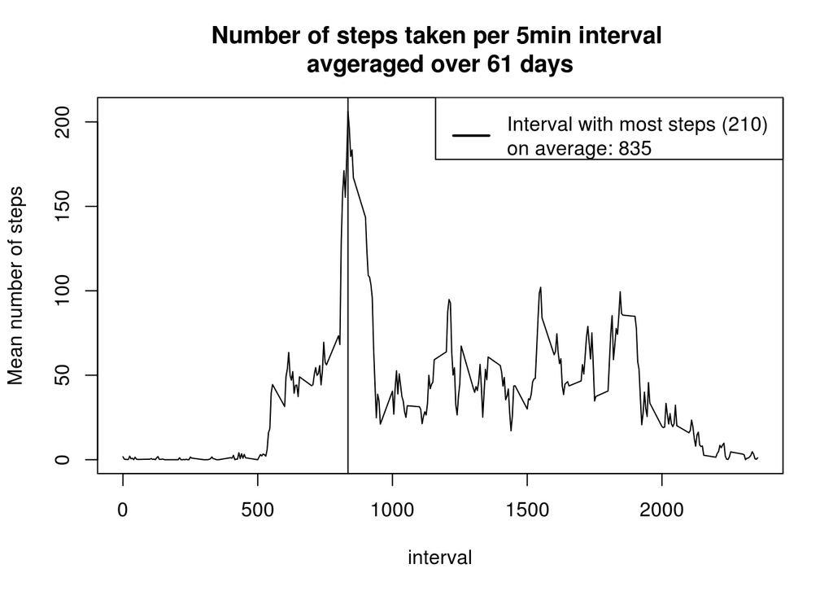

```r
step_mean_per_interval= activity[, mean(steps, na.rm=TRUE), by=interval]

plot(step_mean_per_interval,
    type='l',
    main= paste('Number of steps taken per 5min interval \navgeraged over',
                length(step_sum_per_day),'days'
         ),
    ylab='Mean number of steps'
    )

pos_max= which.max(step_mean_per_interval[,V1])
max_interval= step_mean_per_interval[pos_max, interval]
abline(v= max_interval)
legend('topright',
        paste0('Interval with most steps (', signif(step_mean_per_interval[pos_max, V1],2),
            ') \non average: ', max_interval
            ),
        lwd=2
    )
```

## Imputing missing values

1. Calculate and report the total number of missing values in the dataset (i.e. the total number of rows with NAs)

```r
idx_na=is.na(activity[,steps])
num_na=sum(idx_na)
```

Number of intervals without “steps” measured: 2304.

2. Devise a strategy for filling in all of the missing values in the dataset. The strategy does not need to be sophisticated. For example, you could use the mean/median for that day, or the mean for that 5-minute interval, etc.

```r
step_means_to_impute= as.double(
                     step_mean_per_interval[interval== activity[idx_na, interval], V1]
                     )
```

Retrieve the mean steps per interval for every interval, where activity$steps missing values.

3. Create a new dataset that is equal to the original dataset but with the missing data filled in.

```r
activity[,imputed_steps := as.double(activity$steps)]
```

```
##        steps       date interval imputed_steps
##     1:    NA 2012-10-01        0            NA
##     2:    NA 2012-10-01        5            NA
##     3:    NA 2012-10-01       10            NA
##     4:    NA 2012-10-01       15            NA
##     5:    NA 2012-10-01       20            NA
##    ---
## 17564:    NA 2012-11-30     2335            NA
## 17565:    NA 2012-11-30     2340            NA
## 17566:    NA 2012-11-30     2345            NA
## 17567:    NA 2012-11-30     2350            NA
## 17568:    NA 2012-11-30     2355            NA
```

```r
activity[idx_na, imputed_steps := step_means_to_impute]
```

```
##        steps       date interval imputed_steps
##     1:    NA 2012-10-01        0     1.7169811
##     2:    NA 2012-10-01        5     0.3396226
##     3:    NA 2012-10-01       10     0.1320755
##     4:    NA 2012-10-01       15     0.1509434
##     5:    NA 2012-10-01       20     0.0754717
##    ---
## 17564:    NA 2012-11-30     2335     4.6981132
## 17565:    NA 2012-11-30     2340     3.3018868
## 17566:    NA 2012-11-30     2345     0.6415094
## 17567:    NA 2012-11-30     2350     0.2264151
## 17568:    NA 2012-11-30     2355     1.0754717
```

Copy the old “steps” column, but as type double. Insert the means per interval at the missing values.

4. 1. Make a histogram of the total number of steps taken each day and Calculate and report the mean and median total number of steps taken per day.

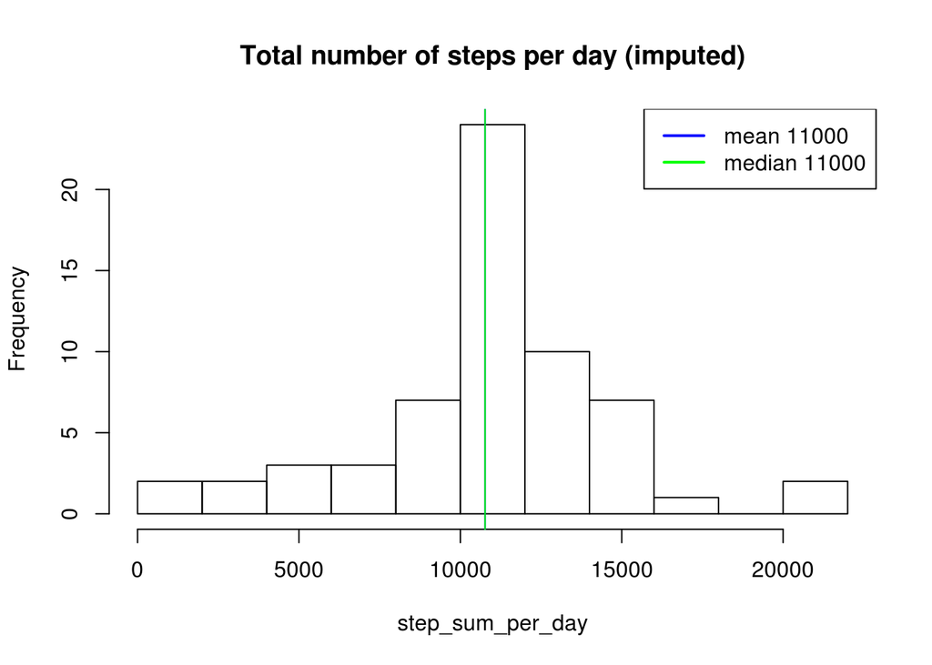

```r
step_sum_per_day= activity[,  sum(imputed_steps, na.rm=TRUE), by=date][,V1]

hist(step_sum_per_day, breaks=10, main='Total number of steps per day (imputed)')

abline(v=mean(step_sum_per_day), col='blue')
abline(v=median(step_sum_per_day), col='green')
legend('topright',
             c(paste('mean', signif(mean(step_sum_per_day),2)),
                 paste('median', signif(median(step_sum_per_day),2))
                 ),
             col=c('blue','green'),
             lwd=2
             )
```

4. 2. Do these values differ from the estimates from the first part of the assignment? What is the impact of imputing missing data on the estimates of the total daily number of steps? The imputation of missing values increases both mean and median, since the “sum” function treated them as zero before.

Yes, mean and median increased compared to raw data. In the “sum per day” computation they were treated as zero before. Now we imputed values>0 and compute the mean/median over same number of elements, consequently it increased.

## Are there differences in activity patterns between weekdays and weekends?

1. Create a new factor variable in the dataset with two levels – “weekday” and “weekend” indicating whether a given date is a weekday or weekend day.

```r
weekend_tag = ifelse(weekdays(activity$date)=='Sunday' | weekdays(activity$date)=='Saturday',
                     'weekend',
                     'weekday'
                     )
activity[, work:= factor(weekend_tag, levels=c('weekend','weekday'))]
```

```
##        steps       date interval imputed_steps    work
##     1:    NA 2012-10-01        0     1.7169811 weekday
##     2:    NA 2012-10-01        5     0.3396226 weekday
##     3:    NA 2012-10-01       10     0.1320755 weekday
##     4:    NA 2012-10-01       15     0.1509434 weekday
##     5:    NA 2012-10-01       20     0.0754717 weekday
##    ---
## 17564:    NA 2012-11-30     2335     4.6981132 weekday
## 17565:    NA 2012-11-30     2340     3.3018868 weekday
## 17566:    NA 2012-11-30     2345     0.6415094 weekday
## 17567:    NA 2012-11-30     2350     0.2264151 weekday
## 17568:    NA 2012-11-30     2355     1.0754717 weekday
```

2. Make a panel plot containing a time series plot (i.e. type = “l”) of the 5-minute interval (x-axis) and the average number of steps taken, averaged across all weekday days or weekend days (y-axis).

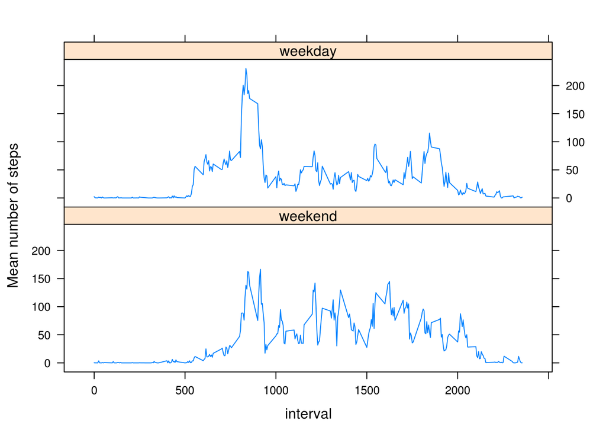

```r
step_mean_per_work_interval= activity[,
                                      mean(imputed_steps, na.rm=T),
                                      by= .(interval,work)
                                      ]

xyplot(V1 ~ interval|work,
       data=step_mean_per_work_interval,
       type='l',
       layout=c(1,2),
       ylab='Mean number of steps'
       )
```

This info suggests to impute NAs by interval with respect to the weekday.